# Active-power forecasting project

```r
# Select the total power and average wind speed

turbine_power <- subset(turbine_data_transformed, select=-c(month, year, day, avg_wind_speed))
head(turbine_power)
```

```
## # A tibble: 6 × 1
##   total_power
##         <dbl>
## 1      27576.
## 2      48502.
## 3      45893.
## 4      51954.
## 5      34469.
## 6      19570.
```

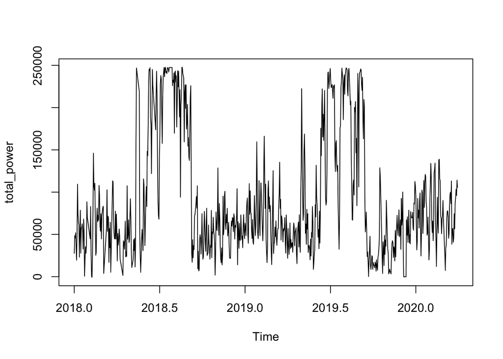

```r
# use subset to only keep windpower column and exculde everything else
# Create time series object and plot time series

power_ts <- ts(turbine_power, start=c(2018, 1, 1), frequency = 365)
# Create time series object and plot time series
# time series starts at 2018 jan 1st and there is 365 day a year

plot(power_ts)
```

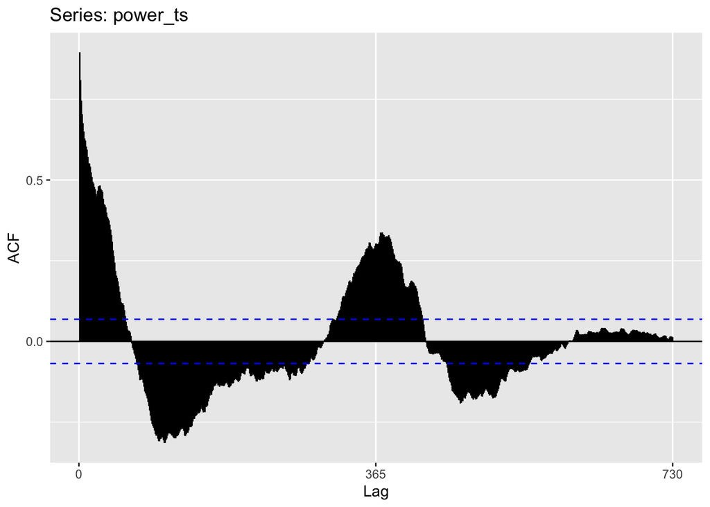

```r
ggAcf(power_ts)
```

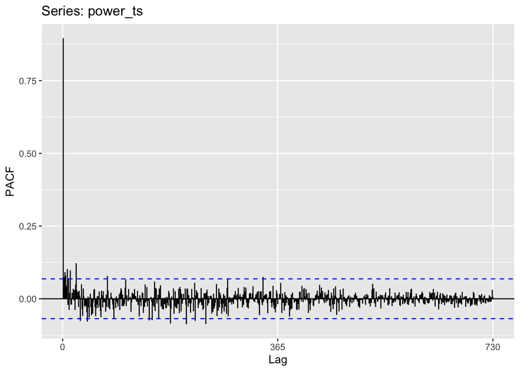

```r
ggPacf(power_ts)
```

## we see a slow decay in ACF plot. This is indicative of a non-stationary series.And From the PACF plot has a significant spike at lag1 which telling us we probably need to start with a AR 1 model

## Create an AR(1) model

```r
fit_AR1 <- sarima(power_ts, 1, 0, 0)
```

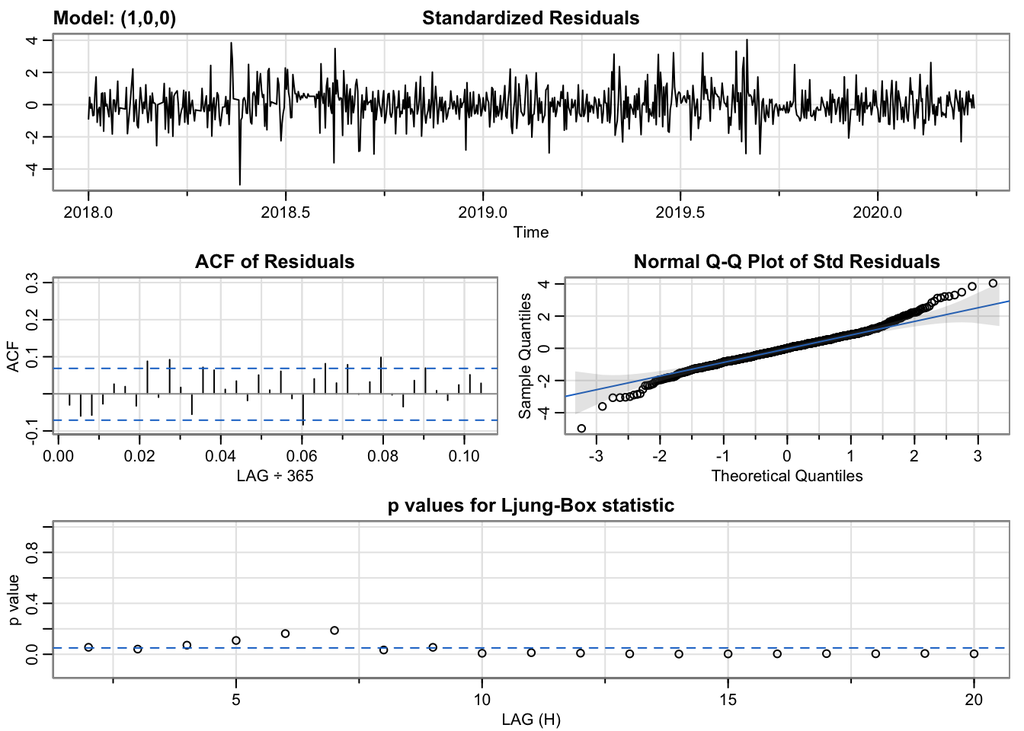

```r
summary(fit_AR1)
```

```
##                    Length Class  Mode
## fit                14     Arima  list
## degrees_of_freedom  1     -none- numeric
## ttable              8     -none- numeric
## AIC                 1     -none- numeric
## AICc                1     -none- numeric
## BIC                 1     -none- numeric
```

```r
fit_AR1
```

```
## $fit
##
## Call:
## arima(x = xdata, order = c(p, d, q), seasonal = list(order = c(P, D, Q), period = S),
##     xreg = xmean, include.mean = FALSE, transform.pars = trans, fixed = fixed,
##     optim.control = list(trace = trc, REPORT = 1, reltol = tol))
##
## Coefficients:
##          ar1     xmean
##       0.8961  90767.85
## s.e.  0.0154  10455.93
##
## sigma^2 estimated as 989002570:  log likelihood = -9656.35,  aic = 19318.69
##
## $degrees_of_freedom
## [1] 818
##
## $ttable
##         Estimate         SE t.value p.value
## ar1       0.8961     0.0154 58.1958       0
## xmean 90767.8549 10455.9345  8.6810       0
##
## $AIC
## [1] 23.55938
##
## $AICc
## [1] 23.5594
##
## $BIC
## [1] 23.57661
```

```r
fit2_AR1 <- arima(power_ts, c(1,0,0))
summary(fit2_AR1)
```

```
##
## Call:
## arima(x = power_ts, order = c(1, 0, 0))
##
## Coefficients:
##          ar1  intercept
##       0.8961   90767.85
## s.e.  0.0154   10455.93
##
## sigma^2 estimated as 989002570:  log likelihood = -9656.35,  aic = 19318.69
##
## Training set error measures:
##                    ME     RMSE      MAE  MPE MAPE     MASE        ACF1
## Training set 57.05726 31448.41 23541.64 -Inf  Inf 1.006564 -0.03001518
```

## AR1 did solid as the QQ plot fit a relatively stright line and ACF of residual seems stationary, but the p value are mostly less than 0.05, signifying not white noise.

## Now that’s look at an AR(2) model

```r
fit_AR2 <- sarima(power_ts, 2, 0, 0)
```

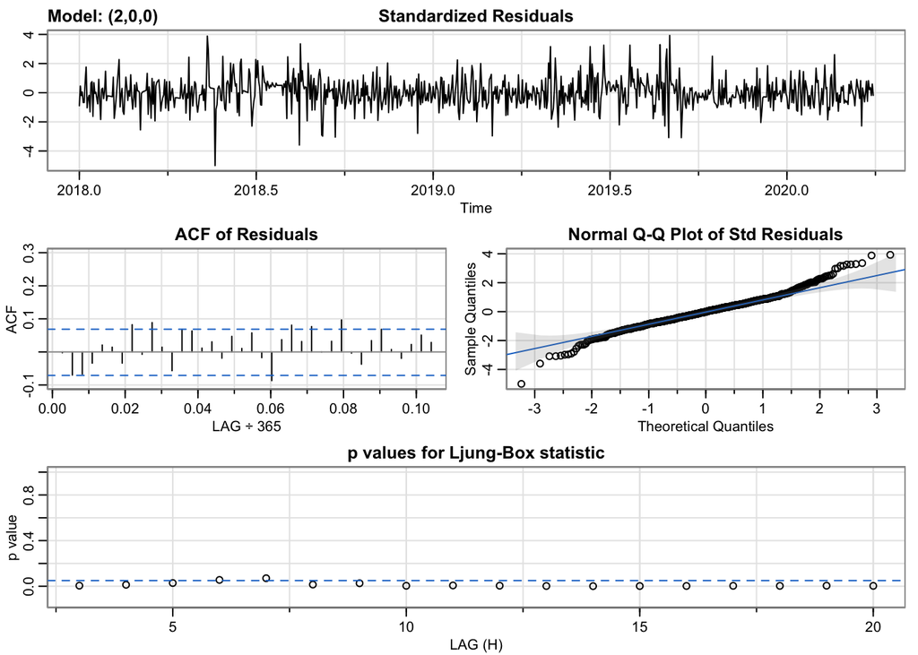

```r
summary(fit_AR2)
```

```
##                    Length Class  Mode
## fit                14     Arima  list
## degrees_of_freedom  1     -none- numeric
## ttable             12     -none- numeric
## AIC                 1     -none- numeric
## AICc                1     -none- numeric
## BIC                 1     -none- numeric
```

```r
fit_AR1
```

```
## $fit
##
## Call:
## arima(x = xdata, order = c(p, d, q), seasonal = list(order = c(P, D, Q), period = S),
##     xreg = xmean, include.mean = FALSE, transform.pars = trans, fixed = fixed,
##     optim.control = list(trace = trc, REPORT = 1, reltol = tol))
##
## Coefficients:
##          ar1     xmean
##       0.8961  90767.85
## s.e.  0.0154  10455.93
##
## sigma^2 estimated as 989002570:  log likelihood = -9656.35,  aic = 19318.69
##
## $degrees_of_freedom
## [1] 818
##
## $ttable
##         Estimate         SE t.value p.value
## ar1       0.8961     0.0154 58.1958       0
## xmean 90767.8549 10455.9345  8.6810       0
##
## $AIC
## [1] 23.55938
##
## $AICc
## [1] 23.5594
##
## $BIC
## [1] 23.57661
```

```r
fit2_AR2 <- arima(power_ts, c(2,0,0))
summary(fit2_AR2)
```

```
##
## Call:
## arima(x = power_ts, order = c(2, 0, 0))
##
## Coefficients:
##          ar1     ar2  intercept
##       0.8661  0.0332   90759.76
## s.e.  0.0349  0.0349   10771.81
##
## sigma^2 estimated as 987915484:  log likelihood = -9655.9,  aic = 19319.79
##
## Training set error measures:
##                    ME     RMSE      MAE  MPE MAPE     MASE         ACF1
## Training set 61.19119 31431.12 23505.94 -Inf  Inf 1.005037 -0.002523092
```

## we still get that a low p value, which telling us we probaly need to tune our model a bit more

## Now I want to see the effect of differencing. Since we are adding a differcing in the model it might be a good idea to add a MA 1 term to even that out.

#ARIMA model(1, 1, 1) to create a model where Residuals are White Noise

```r
fit_model <- sarima(power_ts, 1, 1, 1)
```

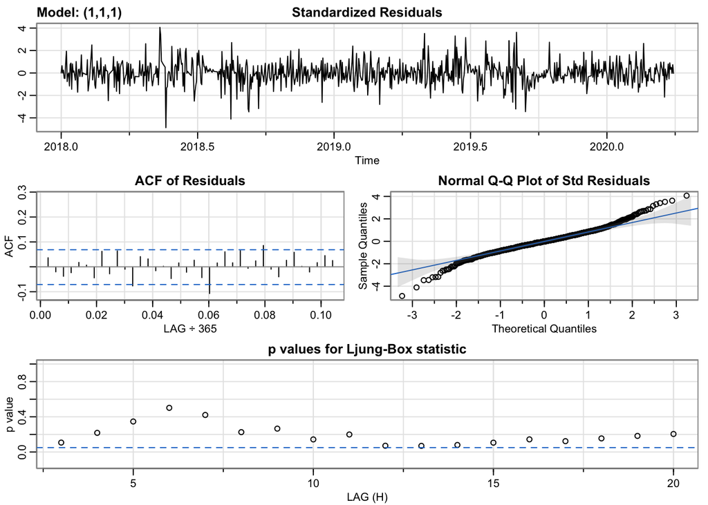

```r
summary(fit_model)
```

```
##                    Length Class  Mode
## fit                14     Arima  list
## degrees_of_freedom  1     -none- numeric
## ttable             12     -none- numeric
## AIC                 1     -none- numeric
## AICc                1     -none- numeric
## BIC                 1     -none- numeric
```

```r
fit_model
```

```
## $fit
##
## Call:
## arima(x = xdata, order = c(p, d, q), seasonal = list(order = c(P, D, Q), period = S),
##     xreg = constant, transform.pars = trans, fixed = fixed, optim.control = list(trace = trc,
##         REPORT = 1, reltol = tol))
##
## Coefficients:
##          ar1      ma1  constant
##       0.7256  -0.9182   51.3719
## s.e.  0.0380   0.0208  327.5608
##
## sigma^2 estimated as 967634432:  log likelihood = -9635.02,  aic = 19278.04
##
## $degrees_of_freedom
## [1] 816
##
## $ttable
##          Estimate       SE  t.value p.value
## ar1        0.7256   0.0380  19.1062  0.0000
## ma1       -0.9182   0.0208 -44.1127  0.0000
## constant  51.3719 327.5608   0.1568  0.8754
##
## $AIC
## [1] 23.5385
##
## $AICc
## [1] 23.53854
##
## $BIC
## [1] 23.5615
```

```r
fit_model1 <- arima(power_ts, c(1, 1, 1))
summary(fit_model1)
```

```
##
## Call:
## arima(x = power_ts, order = c(1, 1, 1))
##
## Coefficients:
##          ar1      ma1
##       0.7255  -0.9181
## s.e.  0.0380   0.0208
##
## sigma^2 estimated as 967663320:  log likelihood = -9635.03,  aic = 19276.06
##
## Training set error measures:
##                    ME     RMSE      MAE  MPE MAPE      MASE       ACF1
## Training set 204.7778 31088.31 22842.33 -Inf  Inf 0.9766636 0.03624296
```

```r
forecast(fit_model1)
```

```
##           Point Forecast        Lo 80    Hi 80       Lo 95    Hi 95
## 2020.2466      100060.42   60194.8235 139926.0   39091.254 161029.6
## 2020.2493       96065.52   44828.2243 147302.8   17704.839 174426.2
## 2020.2521       93167.09   35429.2645 150904.9    4864.703 181469.5
## 2020.2548       91064.20   29070.4239 153058.0   -3747.097 185875.5
## 2020.2575       89538.48   24507.7281 154569.2   -9917.470 188994.4
## 2020.2603       88431.52   21083.8043 155779.2  -14567.921 191431.0
## 2020.2630       87628.38   18413.1958 156843.6  -18227.111 193483.9
## 2020.2658       87045.68   16255.4889 157835.9  -21218.577 195309.9
## 2020.2685       86622.92   14454.4495 158791.4  -23749.230 196995.1
## 2020.2712       86316.19   12905.5630 159726.8  -25955.674 198588.1
## 2020.2740       86093.65   11537.4223 160649.9  -27930.258 200117.5
## 2020.2767       85932.18   10300.4712 161563.9  -29736.539 201600.9
## 2020.2795       85815.04    9159.9098 162470.2  -31418.864 203048.9
## 2020.2822       85730.04    8091.0785 163369.0  -33008.508 204468.6
## 2020.2849       85668.38    7076.3772 164260.4  -34527.716 205864.5
## 2020.2877       85623.64    6103.1685 165144.1  -35992.426 207239.7
## 2020.2904       85591.18    5162.3302 166020.0  -37414.131 208596.5
## 2020.2932       85567.63    4247.2437 166888.0  -38801.168 209936.4
## 2020.2959       85550.54    3353.0814 167748.0  -40159.626 211260.7
## 2020.2986       85538.14    2476.3014 168600.0  -41493.982 212570.3
## 2020.3014       85529.15    1614.2877 169444.0  -42807.557 213865.9
## 2020.3041       85522.62     765.0923 170280.2  -44102.835 215148.1
## 2020.3068       85517.89     -72.7489 171108.5  -45381.696 216417.5
## 2020.3096       85514.45    -900.3493 171929.3  -46645.583 217674.5
## 2020.3123       85511.96   -1718.5667 172742.5  -47895.619 218919.5
## 2020.3151       85510.15   -2528.0724 173548.4  -49132.694 220153.0
## 2020.3178       85508.84   -3329.4010 174347.1  -50357.526 221375.2
## 2020.3205       85507.89   -4122.9864 175138.8  -51570.706 222586.5
## 2020.3233       85507.20   -4909.1876 175923.6  -52772.731 223787.1
## 2020.3260       85506.70   -5688.3079 176701.7  -53964.028 224977.4
## 2020.3288       85506.33   -6460.6085 177473.3  -55144.967 226157.6
## 2020.3315       85506.07   -7226.3187 178238.5  -56315.880 227328.0
## 2020.3342       85505.88   -7985.6430 178997.4  -57477.065 228488.8
## 2020.3370       85505.74   -8738.7665 179750.2  -58628.795 229640.3
## 2020.3397       85505.64   -9485.8591 180497.1  -59771.321 230782.6
## 2020.3425       85505.57  -10227.0780 181238.2  -60904.879 231916.0
## 2020.3452       85505.51  -10962.5704 181973.6  -62029.689 233040.7
## 2020.3479       85505.48  -11692.4748 182703.4  -63145.961 234156.9
## 2020.3507       85505.45  -12416.9221 183427.8  -64253.893 235264.8
```

[output cut: 676 more lines]

```
## 2022.2055       85505.37 -238963.0499 409973.8 -410726.258 581737.0
## 2022.2082       85505.37 -239180.7878 410191.5 -411059.259 582070.0
## 2022.2110       85505.37 -239398.3798 410409.1 -411392.038 582402.8
## 2022.2137       85505.37 -239615.8262 410626.6 -411724.593 582735.3
## 2022.2164       85505.37 -239833.1273 410843.9 -412056.926 583067.7
## 2022.2192       85505.37 -240050.2833 411061.0 -412389.038 583399.8
## 2022.2219       85505.37 -240267.2946 411278.0 -412720.928 583731.7
## 2022.2247       85505.37 -240484.1614 411494.9 -413052.597 584063.3
## 2022.2274       85505.37 -240700.8840 411711.6 -413384.046 584394.8
## 2022.2301       85505.37 -240917.4627 411928.2 -413715.274 584726.0
## 2022.2329       85505.37 -241133.8978 412144.6 -414046.283 585057.0
## 2022.2356       85505.37 -241350.1897 412360.9 -414377.073 585387.8
## 2022.2384       85505.37 -241566.3384 412577.1 -414707.644 585718.4
## 2022.2411       85505.37 -241782.3445 412793.1 -415037.997 586048.7
## 2022.2438       85505.37 -241998.2080 413009.0 -415368.132 586378.9
```

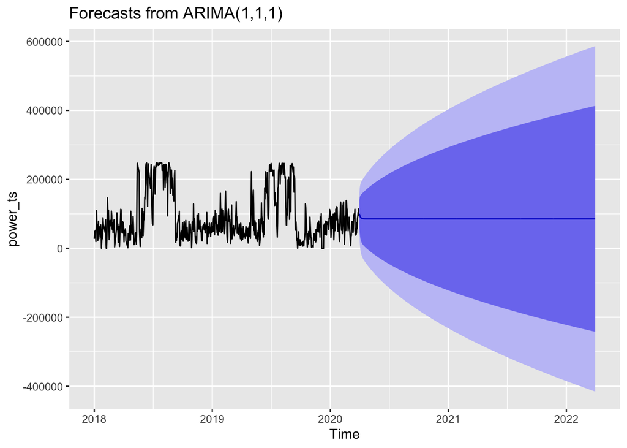

```r
autoplot(forecast(fit_model1))
```

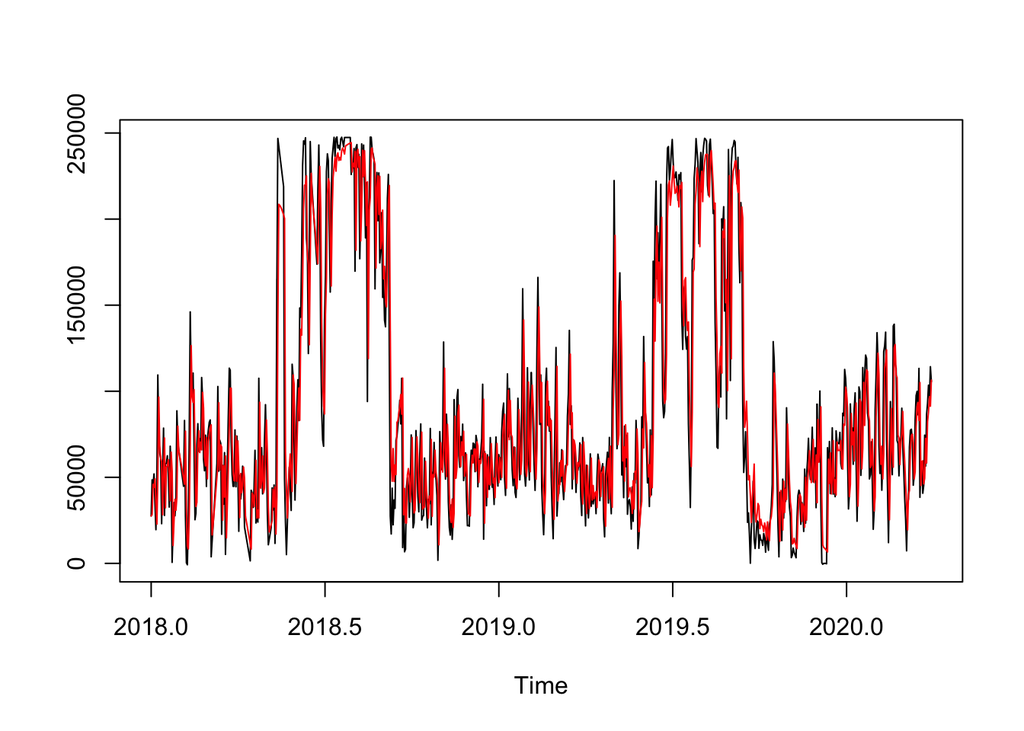

```r
ts.plot(power_ts, fitted(fit_model1), gpars=list(col=c("black","red")))
```

# Here We could see that the p value looks much better

## I used ZNZ for the model is because we don’t know if error is additive or multiplcative and there is not a trend in the dataset, and we aren’t sure if there is seaonality.

```r
power_ets <- ets(power_ts, model = "ZNZ")
summary(power_ets)
```

```
## ETS(A,N,N)
##
## Call:
##  ets(y = power_ts, model = "ZNZ")
##
##   Smoothing parameters:
##     alpha = 0.8867
##
##   Initial states:
##     l = 52549.6037
##
##   sigma:  32185.95
##
##      AIC     AICc      BIC
## 22527.66 22527.68 22541.78
##
## Training set error measures:
##                    ME     RMSE      MAE  MPE MAPE      MASE       ACF1
## Training set 73.96237 32146.68 23273.39 -Inf  Inf 0.5364177 0.01479836
```

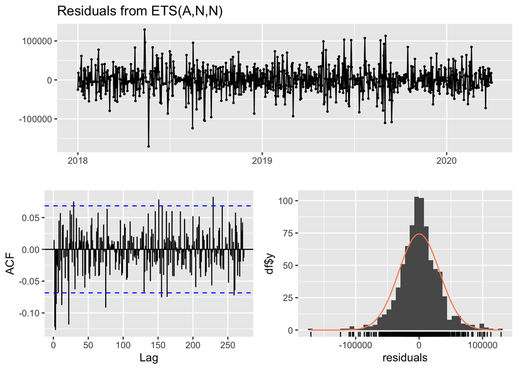

```
##
##  Ljung-Box test
##
## data:  Residuals from ETS(A,N,N)
## Q* = 209.91, df = 162, p-value = 0.006693
##
## Model df: 2.   Total lags used: 164
```

```r
checkresiduals(power_ets)
```

## none of the simple arima model could put an accurate forecast as the forecast plot looks flat, which telling us that we need a seasonal arima model to catch the seasonlity in the dataset.